# Lecture 8: Parametric Regression Models

STA310 Survival Analysis · Collett Chapter 5

2026-10-06

## Today

1. Why parametric models?
2. Distributions: exponential, Weibull, log-logistic, log-normal
3. Likelihood with censoring
4. PH and AFT parametrizations
5. Fitting in R: `survreg` and `flexsurvreg`
6. Choosing a distribution
7. Predictions and extrapolation

**Learning goals**

You can

- write the likelihood of a parametric model with censoring
- interpret Weibull coefficients as hazard ratios and as time ratios
- fit and compare models in R, and predict survival, median and mean
- explain the risks of extrapolation

## Recap and motivation

- Lectures 2-3: Kaplan-Meier, log-rank: no model for $S(t)$.
- Lectures 4-5: Cox model $h(t \mid x) = h_0(t)\exp(\beta' x)$, $h_0(t)$ left **unspecified**; Lectures 6-7: model checking for Cox.

**Today**: specify the whole distribution of $T$ with a few parameters.

**Note**

Same data, same questions (effect of treatment, prognosis). A new trade-off: **more information and precision if the model is right, bias if it is wrong**.

# Why parametric?

## What do we gain?

- **Full distribution**: $S(t)$, $h(t)$, quantiles and mean for any covariate profile
- **Smooth** hazard and survival curves (KM and Cox baseline are step functions)
- **Absolute risks and predictions**: e.g. “5-year survival for a 70-year-old with complete residual disease”
- **Extrapolation** beyond follow-up (e.g. cost-effectiveness analyses), with caution
- **Efficiency**: smaller standard errors when the model is correct
- Useful in **small samples** where the Cox partial likelihood discards information
- Direct **time-scale** interpretation (AFT): “survival is prolonged by a factor …”

**Warning**

**Cost**: we assume a distributional form. Wrong form gives biased estimates, and extrapolation is entirely model-driven.

## Recap of relations

$$S(t) = P(T > t), \quad h(t) = \frac{f(t)}{S(t)}, \quad H(t) = \int_0^t h(u)\,du = -\log S(t)$$

$$f(t) = h(t) S(t), \qquad S(t) = \exp\{-H(t)\}$$

A parametric model = a choice of $h(t;\theta)$ (equivalently $S$ or $f$) with a small parameter vector $\theta$.

# Distributions

## Exponential: constant hazard

$$h(t) = \lambda, \qquad S(t) = e^{-\lambda t}, \qquad \text{median} = \frac{\log 2}{\lambda}, \qquad E(T) = \frac{1}{\lambda}$$

- “No memory”: the risk does not depend on time already survived
- One parameter. Rarely realistic for a whole disease course, but a useful reference
- Both PH and AFT

## Weibull: monotone hazard

$$h(t) = \lambda\gamma t^{\gamma-1}, \qquad S(t) = \exp(-\lambda t^{\gamma})$$

- Shape $\gamma$: $\gamma < 1$ decreasing hazard, $\gamma = 1$ exponential, $\gamma > 1$ increasing
- Hazard is always monotone
- The Weibull (including the exponential) is the only family that is both PH and AFT
- Median: $\{\log 2/\lambda\}^{1/\gamma}$

Medical interpretation: $\gamma > 1$ e.g. ageing, wear (IUD, graft failure); $\gamma < 1$ e.g. early post-operative risk that declines.

## Log-logistic and log-normal: non-monotone hazards

**Log-logistic**: $S(t) = \dfrac{1}{1 + \theta t^{\kappa}}$, $h(t) = \dfrac{\theta\kappa t^{\kappa-1}}{1+\theta t^\kappa}$

- $\kappa \le 1$: decreasing hazard; $\kappa > 1$: rises to a peak, then falls
- Closed-form $S(t)$ (convenient); AFT, and proportional **odds** model

**Log-normal**: $\log T \sim N(\mu, \sigma^2)$, $S(t) = 1 - \Phi\{(\log t - \mu)/\sigma\}$ (with covariates, $\mu$ is replaced by $\eta = \beta'x$)

- Hazard rises then falls to 0 (slowly)
- AFT only, no closed-form $S(t)$

Typical uses: risk peaks after some time, e.g. after surgery or at the start of an infection; cancer relapse.

## Gompertz: exponentially changing hazard

$$h(t) = \exp(\alpha + \xi t)$$

- Log hazard linear in time; $\xi > 0$ increasing hazard
- Standard for **adult human mortality** (actuarial science, demography)
- PH model (Collett 5.8). Available as `dist = "gompertz"` in `flexsurv`

Other families (generalized gamma, inverse Gaussian) exist; we skip them.

## Hazard shapes

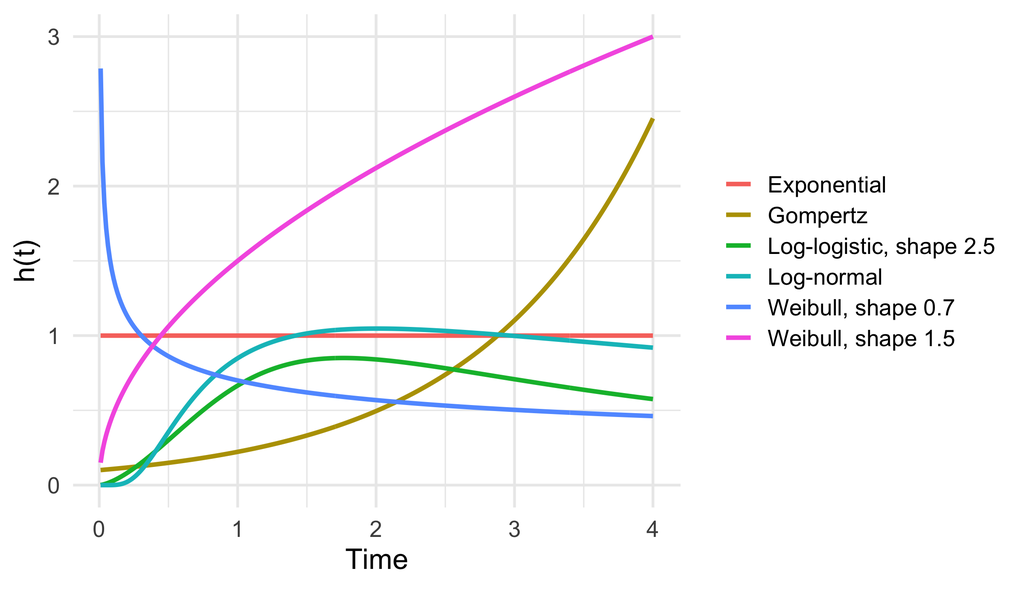

## Comparison of distributions

| Distribution | Hazard shape | PH | AFT | Typical use |
| --- | --- | --- | --- | --- |
| Exponential | constant | yes | yes | reference; short follow-up, stable risk |
| Weibull | monotone up or down | yes | yes | default first choice; wear-out, early risk |
| Log-logistic | up then down (or decreasing) | no (PO) | yes | peaked risk, closed-form $S$ |
| Log-normal | up then down | no | yes | peaked risk, e.g. incubation times |
| Gompertz | exponential up or down | yes | no | adult mortality |
| Cox (for contrast) | unspecified | yes | no | default when shape is unimportant |

# Likelihood with censoring

## Maximum likelihood for censored data

Data $(t_i, \delta_i)$, $i=1,\dots,n$, independent censoring, parameters $\theta$:

$$L(\theta) = \prod_{i=1}^n f(t_i;\theta)^{\delta_i}\, S(t_i;\theta)^{1-\delta_i}
= \prod_{i=1}^n h(t_i;\theta)^{\delta_i}\, S(t_i;\theta)$$

- Event at $t_i$: the density $f(t_i)$, the “probability” of failing at exactly $t_i$
- Right-censored at $t_i$: $S(t_i)$, we only know $T > t_i$
- Log-likelihood: $\ell(\theta) = \sum_i \{\delta_i \log h(t_i) - H(t_i)\}$

Standard errors from the observed information; Wald, score or likelihood-ratio tests. With covariates, $\theta$ includes $\beta$.

## Example: exponential, by hand

With $h = \lambda$: $\ell(\lambda) = d\log\lambda - \lambda\sum_i t_i$, where $d = \sum\delta_i$ = number of events. So

$$\hat\lambda = \frac{d}{\sum t_i} = \frac{\text{events}}{\text{total time at risk}}$$

```r
lam <- sum(iud$status) / sum(iud$time)
c(events = sum(iud$status), time_at_risk = sum(iud$time), lambda_hat = lam,
  se = lam / sqrt(sum(iud$status)))
```

```
      events time_at_risk   lambda_hat           se
9.000000e+00 1.046000e+03 8.604207e-03 2.868069e-03
```

For the IUD data: 9 discontinuations in 1046 woman-weeks, so $\hat\lambda =$ 0.0086 per week; median 80.6 weeks.

# Two parametrizations

## Proportional hazards form

$$h(t \mid x) = h_0(t)\exp(\beta' x)$$

Same as Cox, but $h_0(t)$ is **parametric**, e.g. Weibull: $h_0(t) = \lambda\gamma t^{\gamma-1}$.

- $\exp(\beta_j)$ = hazard ratio
- Weibull: $h(t \mid x) = \lambda e^{\beta'x}\gamma t^{\gamma-1}$, still Weibull with the same $\gamma$

## Accelerated failure time (AFT) form

$$\log T = \eta + \sigma W, \qquad \eta = \beta' x = \beta_0 + \beta_1 x_1 + \dots + \beta_p x_p$$

$W$ = error with a fixed distribution (extreme value for Weibull, logistic for log-logistic, normal for log-normal). Equivalent: $S(t \mid x) = S_0\{t\, e^{-\beta' x}\}$.

- $T = \exp(\eta)\cdot e^{\sigma W}$: covariates **rescale time**
- $\exp(\beta_j)$ = **time ratio** (acceleration factor): survival time is **multiplied by $\exp(\beta_j)$** per unit of $x_j$
- $\exp(\beta_j) > 1$: longer survival (beneficial); $< 1$: shorter
- Quantiles (median, …) scale by the same factor

**Note**

Sign conventions differ: in PH a positive coefficient is **harmful**; in AFT it is **beneficial**.

## Weibull: PH and AFT coincide

Weibull with AFT form, $W$ standard minimum extreme value, scale $\sigma = 1/\gamma$:

$$\beta_j^{PH} = -\frac{\beta_j^{AFT}}{\sigma} = -\gamma\,\beta_j^{AFT}$$

$$\text{HR} = \exp(\beta^{PH}) = (\text{TR})^{-\gamma}$$

Example: $\sigma = 0.5$ ($\gamma = 2$), time ratio 1.5 gives HR $= 1.5^{-2} = 0.44$.

- If $\gamma$ is large (hazard strongly increasing), a modest time ratio means a large hazard ratio
- For log-logistic and log-normal there is **no** such HR; only time ratios (or odds ratios for log-logistic)

## Illustration: an AFT effect shifts the curve along the time axis

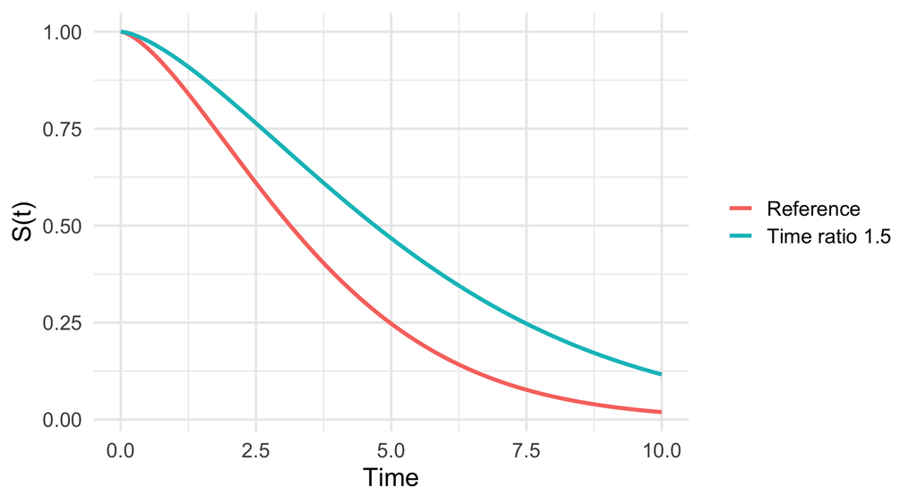

The treated curve is the reference curve stretched horizontally by 1.5: all percentiles are 1.5 times longer.

# Fitting in R

## Example 1: IUD data, no covariates

```r
fit_w <- survreg(Surv(time, status) ~ 1, data = iud, dist = "weibull")
fit_e <- survreg(Surv(time, status) ~ 1, data = iud, dist = "exponential")
c(intercept = coef(fit_w), scale = fit_w$scale, shape = 1 / fit_w$scale)
```

```
intercept.(Intercept)                 scale                 shape
            4.5915178             0.5965153             1.6764030
```

`survreg` parametrization: $\log T = \eta + \sigma W$ with $\eta = \beta_0$ (the `(Intercept)`) when there are no covariates, and `scale` $=\sigma$.

**Important**

Weibull shape (Collett’s $\gamma$) $= 1/$`scale`. And Collett’s $\lambda = \exp(-\text{Intercept}/\sigma)$. Do not read `survreg`’s `Scale` as the shape.

Here shape $=$ 1.68, suggestive of an increasing hazard of discontinuation.

## `flexsurvreg`: hazard-scale parameters

```r
fs_w <- flexsurv::flexsurvreg(Surv(time, status) ~ 1, data = iud, dist = "weibull")
fs_w
```

```
Call:
flexsurv::flexsurvreg(formula = Surv(time, status) ~ 1, data = iud,
    dist = "weibull")

Estimates:
       est      L95%     U95%     se
shape    1.676    0.979    2.872    0.460
scale   98.644   66.086  147.242   20.160

N = 18,  Events: 9,  Censored: 9
Total time at risk: 1046
Log-likelihood = -50.35232, df = 2
AIC = 104.7046
```

`flexsurvreg` reports **shape** and **scale** directly (`scale` $= \lambda^{-1/\gamma}$, the time at which $S = e^{-1}$). `dist = "weibullPH"` gives the PH parametrization with $\lambda$ as in the book.

## Fitted curve against Kaplan-Meier

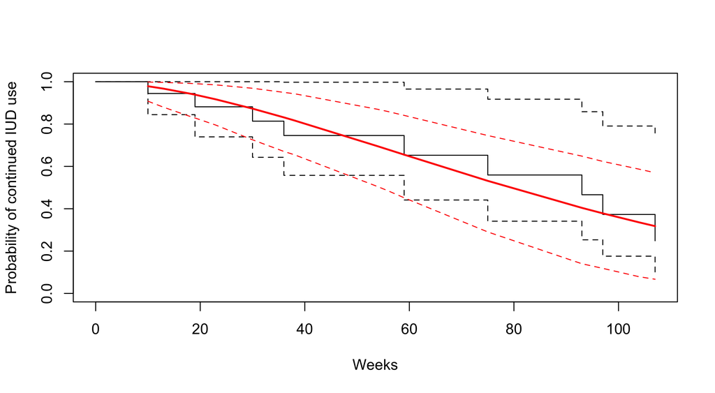

```r
plot(fs_w, xlab = "Weeks", ylab = "Probability of continued IUD use")
```

The smooth Weibull curve (red) with 95% band follows the KM steps (black). With only 18 women, KM’s right tail is very uncertain.

## Exponential or Weibull? Nested models

The exponential is a Weibull with $\gamma = 1$. Likelihood ratio test:

```r
fs_e <- flexsurv::flexsurvreg(Surv(time, status) ~ 1, data = iud, dist = "exp")
lr <- 2 * (fs_w$loglik - fs_e$loglik)
c(LR = lr, p = pchisq(lr, df = 1, lower.tail = FALSE),
  AIC_exp = AIC(fs_e), AIC_weibull = AIC(fs_w))
```

```
          LR            p      AIC_exp  AIC_weibull
  2.89443337   0.08888602 105.59907321 104.70463984
```

LR statistic 2.89 on 1 df, p = 0.089. AIC favours the Weibull. With 9 events the evidence is limited either way.

## Example 2: hypernephroma, nephrectomy and age

36 patients; `nephrectomy` (No/Yes), age group ($<60$, 60-70, $>70$), time and status.

```r
hyper |> count(nephrectomy, age) |> pivot_wider(names_from = age, values_from = n)
```

```
# A tibble: 2 × 4
  nephrectomy `<60` `60-70` `>70`
  <fct>       <int>   <int> <int>
1 No              3       3     1
2 Yes            16       9     4
```

```r
hyper |> summarise(events = sum(status), n = n(), median_time = median(time))
```

```
  events  n median_time
1     32 36        23.5
```

Question: does nephrectomy prolong survival, after allowing for age group?

## Weibull AFT for the hypernephroma data

```r
h_fit <- survreg(Surv(time, status) ~ nephrectomy + age, data = hyper, dist = "weibull")
summary(h_fit)$table
```

```
                     Value Std. Error          z            p
(Intercept)     2.88668426  0.3427839  8.4212940 3.723487e-17
nephrectomyYes  1.17011052  0.3318797  3.5257068 4.223542e-04
age60-70       -0.05822745  0.2852551 -0.2041241 8.382565e-01
age>70         -1.17137057  0.3955227 -2.9615764 3.060686e-03
Log(scale)     -0.34389700  0.1411602 -2.4362181 1.484173e-02
```

Interpretation (time ratios):

```r
tr <- exp(cbind(TR = coef(h_fit), confint(h_fit)))[-1, ]
round(tr, 2)
```

```
                 TR 2.5 % 97.5 %
nephrectomyYes 3.22  1.68   6.18
age60-70       0.94  0.54   1.65
age>70         0.31  0.14   0.67
```

Nephrectomy: time ratio 3.22 (95% CI 1.68 to 6.18): survival times are estimated to be multiplied by about 3.2. Check how wide the interval is: with 36 patients, precision is low.

## Same model, PH parametrization and hazard ratios

```r
h_ph <- flexsurv::flexsurvreg(Surv(time, status) ~ nephrectomy + age, data = hyper, dist = "weibullPH")
round(exp(h_ph$res[-(1:2), c("est", "L95%", "U95%")]), 2)
```

```
                est L95%  U95%
nephrectomyYes 0.19 0.07  0.54
age60-70       1.09 0.49  2.39
age>70         5.22 1.64 16.64
```

These are hazard ratios. Check with the formula: $-\hat\beta^{AFT}/\hat\sigma$ for nephrectomy gives HR $=$ 0.19, same as above.

## Example 3: ovar cancer

26 women, two chemotherapy regimens (`treat`: Single/Combined), `age`, residual disease (`rdisease`: Incomplete/Complete), performance status (`perf`: Good/Poor).

```r
ov_fit <- survreg(Surv(time, status) ~ treat + age + rdisease + perf,
                  data = ovar, dist = "weibull")
broom::tidy(ov_fit, conf.int = TRUE, exponentiate = TRUE) |>
  mutate(across(where(is.numeric), \(x) round(x, 3)))
```

```
# A tibble: 6 × 7
  term             estimate std.error statistic p.value conf.low conf.high
  <chr>               <dbl>     <dbl>     <dbl>   <dbl>    <dbl>     <dbl>
1 (Intercept)        10.5       1.17      8.98    0        8.23     12.8
2 treatCombined       0.518     0.325     1.59    0.111   -0.119     1.16
3 age                -0.065     0.019    -3.34    0.001   -0.103    -0.027
4 rdiseaseComplete   -0.521     0.394    -1.32    0.187   -1.29      0.252
5 perfPoor           -0.087     0.324    -0.268   0.788   -0.721     0.547
6 Log(scale)         -0.653     0.24     -2.72    0.006   NA        NA
```

## Interpreting the ovar output

```r
tr_o <- exp(coef(ov_fit))
```

- **Age**: each extra year multiplies survival time by 0.937, i.e. about 6.3% shorter per year; per 10 years, time ratio 0.52.
- **Combined vs single chemotherapy**: time ratio 1.68; the Wald p-value is 0.11, so no firm conclusion about treatment (n = 26, 12 deaths).
- Scale $\hat\sigma =$ 0.52, so shape $\hat\gamma =$ 1.92: increasing hazard.
- Hazard ratio for age per year: $\exp(-\hat\beta/\hat\sigma) =$ 1.13.

## Example 4: lung cancer, sex

Built-in `lung` data (n = 228, survival in days, `status` 2 = dead, recoded to `dead`).

```r
lung_fit <- survreg(Surv(time, dead) ~ sex + age + ph.ecog, data = lung2, dist = "weibull")
lung_tr <- exp(cbind(TR = coef(lung_fit), confint(lung_fit)))
round(lung_tr, 3)
```

```
                 TR   2.5 %   97.5 %
(Intercept) 791.972 342.693 1830.267
sexFemale     1.493   1.172    1.903
age           0.993   0.979    1.006
ph.ecog       0.712   0.605    0.839
```

Women have a time ratio of 1.49 (95% CI 1.17 to 1.9) relative to men, adjusting for age and ECOG score: survival times are multiplied by about 1.49. Each ECOG point multiplies survival time by 0.71.

## Other distributions with the same covariates

```r
dists <- c("weibull", "lognormal", "loglogistic", "exponential")
aics <- map_dfr(dists, \(d) {
  f <- survreg(Surv(time, dead) ~ sex + age + ph.ecog, data = lung2, dist = d)
  tibble(dist = d, loglik = f$loglik[2], AIC = AIC(f),
         TR_female = exp(coef(f)["sexFemale"]))
})
aics |> mutate(across(where(is.numeric), \(x) round(x, 2)))
```

```
# A tibble: 4 × 4
  dist        loglik   AIC TR_female
  <chr>        <dbl> <dbl>     <dbl>
1 weibull     -1132. 2275.      1.49
2 lognormal   -1147. 2304.      1.69
3 loglogistic -1137. 2285.      1.63
4 exponential -1144. 2295.      1.66
```

The time ratio for sex is fairly similar across the three AFT families, but not identical. Non-nested families (Weibull vs log-normal) can be compared by AIC, not by LR test.

# Choosing a distribution

## Graphical check: Weibull plot

If $T$ is Weibull, $H(t) = \lambda t^\gamma$, so

$$\log H(t) = \log\lambda + \gamma\log t$$

Plot $\log \hat H(t)$ (or $\log\{-\log \hat S(t)\}$ from KM) against $\log t$: roughly a **straight line** with slope $\gamma$. Slope 1 and intercept $\log\lambda$ means exponential. Parallel lines for groups: PH.

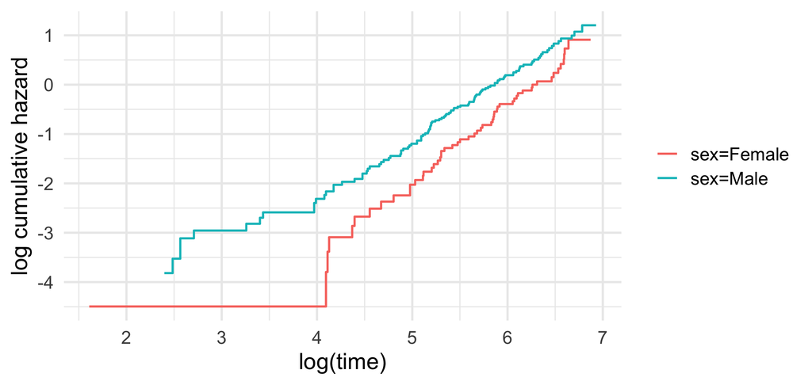

```r
km <- survfit(Surv(time, dead) ~ sex, data = lung2)
tibble(time = km$time, S = km$surv, sex = rep(names(km$strata), km$strata)) |>
  filter(S > 0, S < 1) |>
  ggplot(aes(log(time), log(-log(S)), colour = sex)) + geom_step() +
  labs(x = "log(time)", y = "log cumulative hazard", colour = NULL)
```

## Reading the Weibull plot

- Lines are roughly straight and roughly parallel after the first noisy steps, with slope near the estimated shape 1.37
- Curvature suggests log-logistic or log-normal
- Vertical distance = $\log$ HR; horizontal distance = $\log$ time ratio (same for a Weibull)
- With few events, the plot is noisy: do not over-interpret

Formal alternatives: AIC, LR tests for nested models, a more flexible parametric model (Lecture 9), residuals (Lecture 9).

## Comparing to the Kaplan-Meier curve

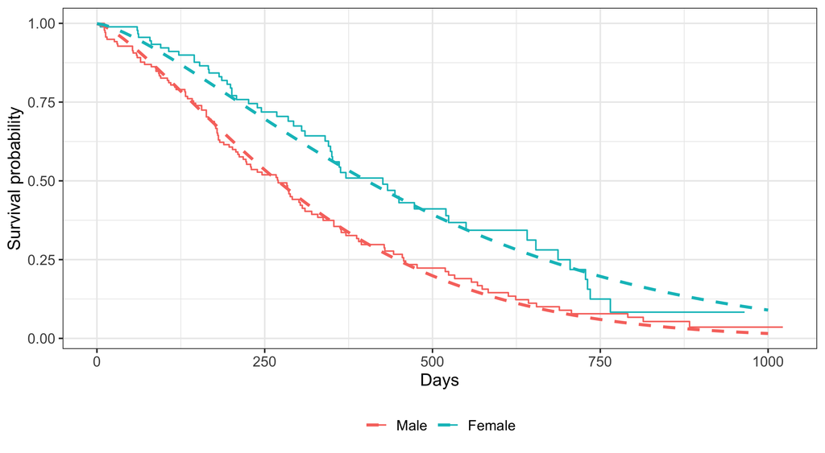

```r
nd <- data.frame(sex = c("Male", "Female"), age = 63, ph.ecog = 1) |>
  mutate(sex = factor(sex, levels = c("Male", "Female")))
pr <- seq(0, 1000, by = 10)
sfun <- map_dfr(1:2, \(i) tibble(time = pr, sex = nd$sex[i],
   S = predict(lung_fit, nd[i, ], type = "quantile", p = seq(0.001, 0.999, length = 999)) |>
        (\(q) approx(q, 1 - seq(0.001, 0.999, length = 999), pr, rule = 2)$y)()))
km2 <- survfit2(Surv(time, dead) ~ sex, data = lung2)
km2 |> ggsurvfit() + labs(x = "Days", y = "Survival probability") +
  geom_line(data = sfun, aes(time, S, colour = sex), linetype = 2, linewidth = 1, inherit.aes = FALSE)
```

Dashed = Weibull prediction for a 63-year-old with ECOG 1 (so not identical to the marginal KM; shown to compare shape and level only).

## AIC and LR tests: nested models

For nested parametric models (same family, different covariates; exponential within Weibull):

$$\text{LR} = -2(\ell_{\text{small}} - \ell_{\text{big}}) \sim \chi^2_{q} \text{ (approx.)}$$

```r
f0 <- survreg(Surv(time, dead) ~ sex + age, data = lung2, dist = "weibull")
f1 <- survreg(Surv(time, dead) ~ sex + age + ph.ecog, data = lung2, dist = "weibull")
anova(f0, f1)
```

```
                Terms Resid. Df    -2*LL     Test Df Deviance     Pr(>Chi)
1           sex + age       224 2294.109          NA       NA           NA
2 sex + age + ph.ecog       222 2264.877 +ph.ecog  2 29.23137 4.492503e-07
```

(Use the same data in both fits: `ph.ecog` has one missing value, which `survreg` drops, so re-fit `f0` on the same rows when comparing.)

## Same rows, please

```r
cc <- lung2 |> drop_na(age, ph.ecog)
f0 <- survreg(Surv(time, dead) ~ sex + age, data = cc, dist = "weibull")
f1 <- survreg(Surv(time, dead) ~ sex + age + ph.ecog, data = cc, dist = "weibull")
anova(f0, f1)
```

```
                Terms Resid. Df    -2*LL     Test Df Deviance     Pr(>Chi)
1           sex + age       223 2281.514          NA       NA           NA
2 sex + age + ph.ecog       222 2264.877 +ph.ecog  1 16.63656 4.527005e-05
```

# Parametric versus Cox

## Weibull versus Cox: same data

If the Weibull model is right, the hazard ratios from Weibull PH and Cox should be similar, with the Weibull slightly more precise.

```r
cox_o <- coxph(Surv(time, status) ~ treat + age + rdisease + perf, data = ovar)
wph_o <- flexsurv::flexsurvreg(Surv(time, status) ~ treat + age + rdisease + perf,
                               data = ovar, dist = "weibullPH")
cmp <- tibble(term = names(coef(cox_o)),
              HR_cox = exp(coef(cox_o)), se_cox = summary(cox_o)$coefficients[, "se(coef)"],
              HR_weibull = exp(wph_o$res[-(1:2), "est"]), se_weibull = wph_o$res[-(1:2), "se"])
cmp |> mutate(across(where(is.numeric), \(x) round(x, 3)))
```

```
# A tibble: 4 × 5
  term             HR_cox se_cox HR_weibull se_weibull
  <chr>             <dbl>  <dbl>      <dbl>      <dbl>
1 treatCombined     0.403  0.654      0.369      0.649
2 age               1.13   0.047      1.13       0.039
3 rdiseaseComplete  2.30   0.79       2.72       0.76
4 perfPoor          1.46   0.644      1.18       0.619
```

## Interpreting the comparison

- Hazard ratios are of the same order: age HR 1.13 (Cox) and 1.13 (Weibull)
- Standard errors are on the log-HR scale in both columns (flexsurv reports the SE of the log-coefficient)
- Large differences would signal a poor Weibull fit or a non-PH hazard
- With 12 events the data cannot say much about differences in efficiency

**Tip**

**Practical advice**: report Cox for the HR when only relative effects matter; use parametric when you need absolute predictions, smooth hazards, or extrapolation. Check the PH/AFT assumption either way.

## Cox versus Weibull: baseline

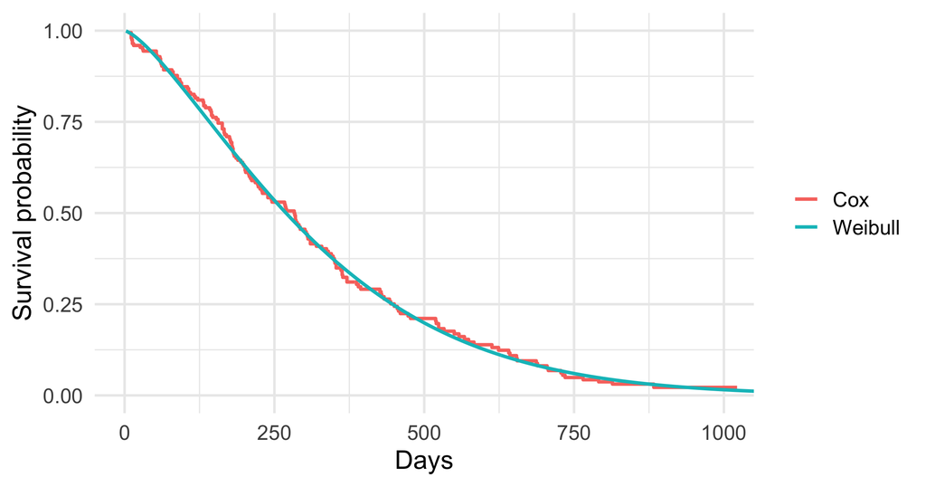

```r
cox_l <- coxph(Surv(time, dead) ~ sex + age + ph.ecog, data = lung2)
nd1 <- data.frame(sex = factor("Male", levels = c("Male", "Female")), age = 63, ph.ecog = 1)
sc <- survfit(cox_l, newdata = nd1)
qs <- seq(0.001, 0.999, length = 999)
wq <- predict(lung_fit, nd1, type = "quantile", p = qs)
ggplot() +
  geom_step(aes(sc$time, sc$surv, colour = "Cox"), linewidth = 1) +
  geom_line(aes(wq, 1 - qs, colour = "Weibull"), linewidth = 1) +
  coord_cartesian(xlim = c(0, 1000)) +
  labs(x = "Days", y = "Survival probability", colour = NULL)
```

Male, age 63, ECOG 1. The curves are close within the observed range: the Weibull is a smoothed version of the Cox prediction.

# Predictions

## Median, mean and restricted mean from a parametric model

For a covariate profile $x$, with fitted $\hat S(t\mid x)$:

- **Median**: $t$ such that $\hat S(t\mid x) = 0.5$ (any percentile $p$: `predict(type = "quantile")`)
- **Mean**: $\int_0^\infty \hat S(t)\,dt$, requires extrapolation to infinity
- **Restricted mean** up to $\tau$: $\int_0^{\tau}\hat S(t)\,dt$, mean time alive within $\tau$

```r
fs_l <- flexsurv::flexsurvreg(Surv(time, dead) ~ sex + age + ph.ecog, data = lung2, dist = "weibull")
nd2 <- data.frame(sex = c("Male", "Female"), age = 63, ph.ecog = 1) |>
  mutate(sex = factor(sex, levels = c("Male", "Female")))
bind_rows(
  summary(fs_l, newdata = nd2, type = "quantile", quantiles = 0.5, tidy = TRUE) |> mutate(what = "median"),
  summary(fs_l, newdata = nd2, type = "mean", tidy = TRUE) |> mutate(what = "mean"),
  summary(fs_l, newdata = nd2, type = "rmst", t = 365, tidy = TRUE) |> mutate(what = "RMST 1 yr")
) |> select(what, sex, est, lcl, ucl) |> mutate(across(where(is.numeric), \(x) round(x)))
```

```
       what    sex est lcl ucl
1    median   Male 269 234 312
2    median Female 402 337 492
3      mean   Male 322 281 369
4      mean Female 481 396 596
5 RMST 1 yr   Male 246 227 264
6 RMST 1 yr Female 287 266 305
```

## Interpretation

For a 63-year-old with ECOG 1, the Weibull model estimates a median survival that is longer for women than men, with the mean larger than the median (right-skewed distribution). The restricted mean is the average number of days alive during the first year, and needs far less extrapolation than the mean.

**Warning**

The **mean** depends on the tail of $S(t)$ beyond follow-up, which is pure model assumption. Prefer **median** and **restricted mean** and state $\tau$.

## Survival probabilities at fixed times

```r
summary(fs_l, newdata = nd2, type = "survival", t = c(180, 365, 730), tidy = TRUE) |>
  select(time, sex, est, lcl, ucl) |> mutate(across(where(is.numeric), \(x) round(x, 3)))
```

```
  time    sex   est   lcl   ucl
1  180   Male 0.671 0.608 0.733
2  365   Male 0.350 0.280 0.423
3  730   Male 0.066 0.035 0.111
4  180 Female 0.794 0.734 0.847
5  365 Female 0.545 0.449 0.630
6  730 Female 0.209 0.120 0.304
```

Absolute risk statements, e.g. “estimated 1-year survival 0.55 for a 63-year-old woman with ECOG 1” follow directly, with confidence intervals.

## Extrapolation: a warning in practice

Experiment: pretend follow-up ended at 300 days (censor everything later), fit models, extrapolate, compare with full KM.

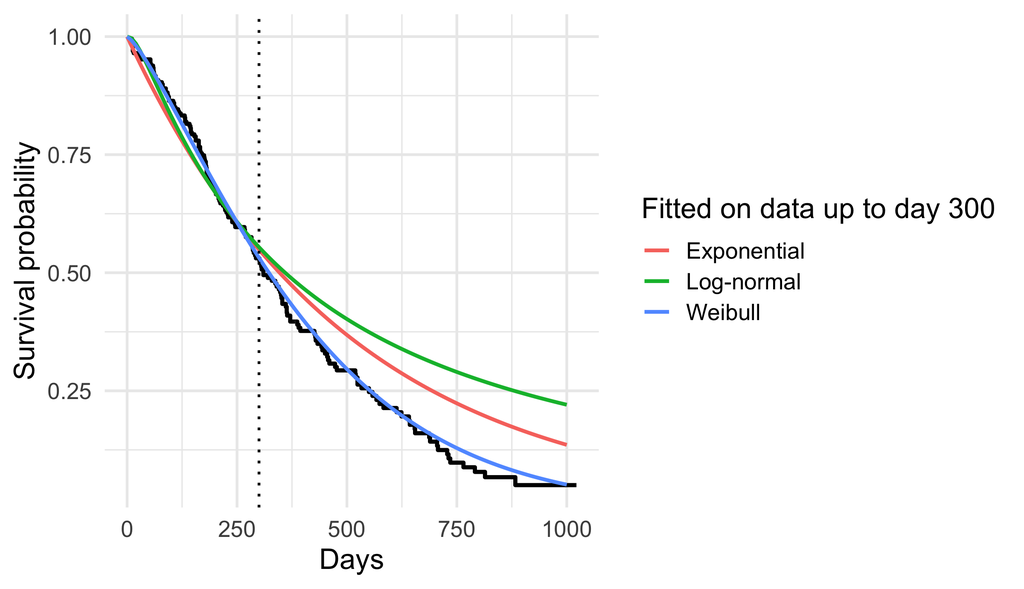

Black: KM using all data. Dotted line: end of “available follow-up”. Models that fit equally well within the first 300 days can diverge widely beyond.

## Extrapolation: rules of thumb

- Within-range fit says little about the tail
- Treat extrapolations as **scenarios**, not estimates; compare several families
- Use external information (registry, mortality tables) to anchor the tail
- Report restricted means with the horizon $\tau$ inside the follow-up where possible
- Prefer flexible models (Lecture 9) to check sensitivity

# Practice

## In-class exercise (10 min)

Ovarian data. Using the Weibull AFT model `ov_fit` (output on the earlier slide):

1. Age has an AFT coefficient of -0.065 and `Scale` 0.52. Compute the time ratio for a woman 10 years older, and the corresponding hazard ratio.
2. Is the sign of the AFT coefficient consistent with the sign of the PH log hazard ratio? Why?
3. Fit `dist = "exponential"` to the same covariates, and test it against the Weibull with a likelihood ratio test. What do you conclude?
4. Predict the median survival (days) for a 60-year-old on combined chemotherapy, incomplete residual disease, good performance.

Hint: `predict(fit, newdata, type = "quantile", p = 0.5)`.

## Quiz

1. A Weibull model has `survreg` Scale 0.5. What is the shape and is the hazard increasing or decreasing?
2. A treatment has a time ratio of 0.7. Is it beneficial?
3. Which distributions can give a hazard ratio? Which only a time ratio?
4. Why is the mean survival a risky quantity to report?

## Take-home messages

- Parametric models specify the **whole** distribution: gain absolute predictions, smooth curves, efficiency; cost: assumptions
- Weibull (monotone hazard) is the workhorse; exponential is a special case; log-logistic and log-normal give peaked hazards
- Likelihood: $f(t)$ for events, $S(t)$ for censored
- **AFT**: $\log T = \eta + \sigma W$, $\eta = \beta'x$, $\exp(\beta)$ = time ratio. **PH**: $\exp(\beta)$ = hazard ratio. Weibull: $\beta^{PH} = -\beta^{AFT}/\sigma$
- `survreg`: shape $= 1/$`scale`; `flexsurvreg`: shape and scale directly, with `summary()` for predictions
- Choose by Weibull plot, AIC, LR tests; compare with Cox
- **Do not extrapolate blindly**; prefer median and restricted mean to mean

**Next lecture**: flexible parametric models and model checking for parametric models (Collett, Chapters 6-7).

**Reading**: Collett, Chapter 5 (sections 5.1-5.7 on distributions, likelihood and the Weibull model; 5.10-5.13 on AFT models; skim 5.8, 5.14-5.17).